# OM Summary Report

North Atlantic Swordfish MSE

Adrian Hordyk adrian@bluematterscience.com

June 20, 2023

# 1 Introduction

This report summarizes the diagnostic checks, the calculated biological reference points, and the estimated stock status relative to those reference points, for all operating models included in the OM Uncertainty Grid.

## 1.1 Operating Models

Table 1. Summary table of the operating model uncertainty grid. `OM.num` can be used to reference the operating models in the tables and figures below.

| OM Number | M | sigmaR | Steepness (h) | Include CAL | Assumed historical increase in catchability | Class |
| --- | --- | --- | --- | --- | --- | --- |
| 000 | 0.2 | 0.2 | 0.88 | TRUE | 1 | Base Case |
| 001 | 0.1 | 0.2 | 0.69 | TRUE | 1 | Reference |
| 002 | 0.1 | 0.2 | 0.8 | TRUE | 1 | Reference |
| 003 | 0.1 | 0.2 | 0.88 | TRUE | 1 | Reference |
| 004 | 0.2 | 0.2 | 0.69 | TRUE | 1 | Reference |
| 005 | 0.2 | 0.2 | 0.8 | TRUE | 1 | Reference |
| 006 | 0.2 | 0.2 | 0.88 | TRUE | 1 | Reference |
| 007 | 0.3 | 0.2 | 0.69 | TRUE | 1 | Reference |
| 008 | 0.3 | 0.2 | 0.8 | TRUE | 1 | Reference |
| 009 | 0.3 | 0.2 | 0.88 | TRUE | 1 | Reference |

# 2 Model Diagnostic Checks

## 2.1 Report Estimated Parameters Near Bounds

Table 2. Table of estimated parameters within 1% of the bounds.

| OM.num | Class | Parameter | Min | Max | Value |
| --- | --- | --- | --- | --- | --- |
| 001 | Reference | Size_DblN_ascend_se_CAN_3(3)_BLK1repl_1950 | 0 | 15 | 14.9961 |
| 002 | Reference | Size_DblN_ascend_se_CAN_3(3)_BLK1repl_1950 | 0 | 15 | 14.9958 |
| 003 | Reference | Size_DblN_ascend_se_CAN_3(3)_BLK1repl_1950 | 0 | 15 | 14.9955 |

# 3 Summary Tables

Table 5. Summary table of the calculated biological reference points and estimated stock status in the terminal year for the OMs in the uncertainty grid.

| OM.num | M | steepness | Class | SB0 | SBMSY | FMSY | MSY_d | MSY_r | SB | SB_SB0 | SB_SBMSY | F_FMSY |
| --- | --- | --- | --- | --- | --- | --- | --- | --- | --- | --- | --- | --- |
| 000 | 0.2 | 0.88 | Base Case | 120417 | 22813.1 | 0.17 | 12833.3 | 12045.6 | 26162.6 | 0.22 | 1.15 | 0.77 |
| 001 | 0.1 | 0.69 | Reference | 416034 | 127168 | 0.05 | 11139 | 10656.3 | 145128 | 0.35 | 1.14 | 0.86 |
| 002 | 0.1 | 0.8 | Reference | 359174 | 94795.5 | 0.07 | 11435.7 | 10950.5 | 104714 | 0.29 | 1.1 | 0.86 |
| 003 | 0.1 | 0.88 | Reference | 324022 | 74016.7 | 0.08 | 11648.6 | 11156.9 | 81458.7 | 0.25 | 1.1 | 0.85 |
| 004 | 0.2 | 0.69 | Reference | 153915 | 42935 | 0.1 | 12109.5 | 11441.4 | 42888 | 0.28 | 1 | 0.9 |
| 005 | 0.2 | 0.8 | Reference | 133478 | 30981 | 0.13 | 12511.3 | 11789.4 | 32081.2 | 0.24 | 1.04 | 0.84 |
| 006 | 0.2 | 0.88 | Reference | 120962 | 23163.4 | 0.17 | 12818.4 | 12034.2 | 26394.5 | 0.22 | 1.14 | 0.77 |
| 007 | 0.3 | 0.69 | Reference | 85800.8 | 22277.3 | 0.14 | 13561.9 | 12583.8 | 30277.9 | 0.35 | 1.36 | 0.63 |
| 008 | 0.3 | 0.8 | Reference | 75196.1 | 15757.7 | 0.18 | 14250.4 | 13131.1 | 25804.7 | 0.34 | 1.64 | 0.54 |
| 009 | 0.3 | 0.88 | Reference | 69484 | 11551.8 | 0.23 | 15009.4 | 13711.9 | 23756.2 | 0.34 | 2.06 | 0.46 |

# 4 Time-Series Plots

## 4.1 SSB

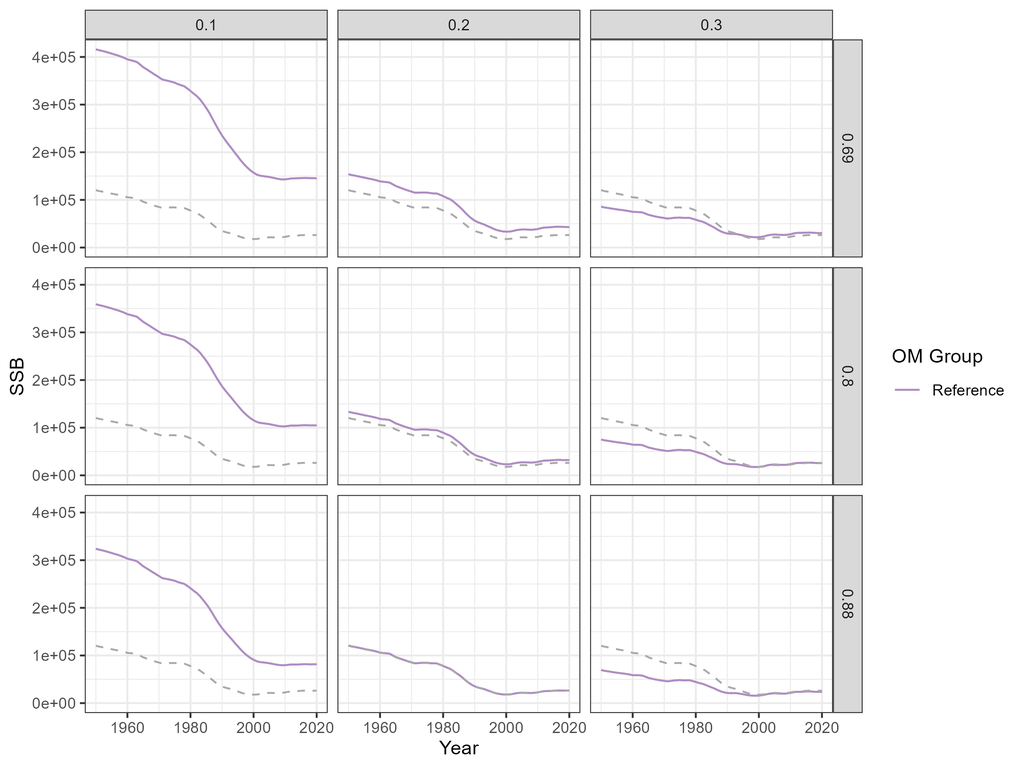

Figure 1. Time-series of estimated spawning stock biomass (SSB) with three levels natural mortality (M; columns) and three levels steepness (h; rows), and the Reference OMs and 0 sets of Robustness OMs (colors). The black dashed line represents the predictions from the 2022 Base Case stock assessment.

## 4.2 Fishing mortality (F)

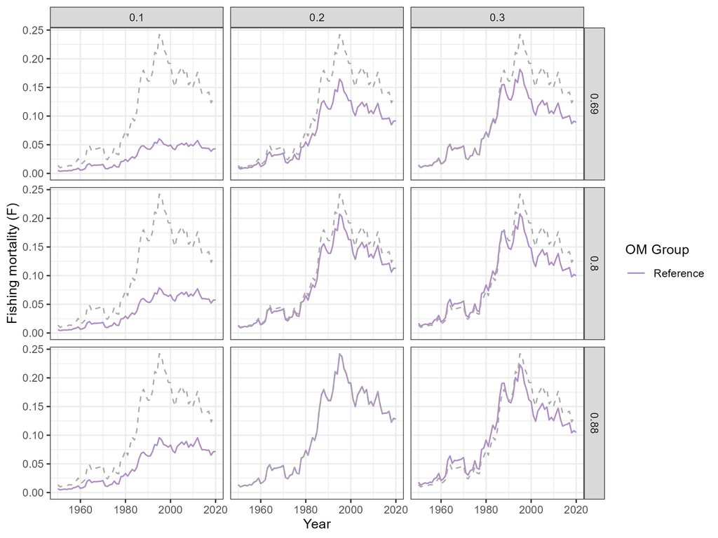

Figure 2. Time-series of estimated fishing mortality (F) with three levels natural mortality (M; columns) and three levels steepness (h; rows), and the Reference OMs and 0 sets of Robustness OMs (colors). The black dashed line represents the predictions from the 2022 Base Case stock assessment.

## 4.3 SB/SB<sub>0</sub>

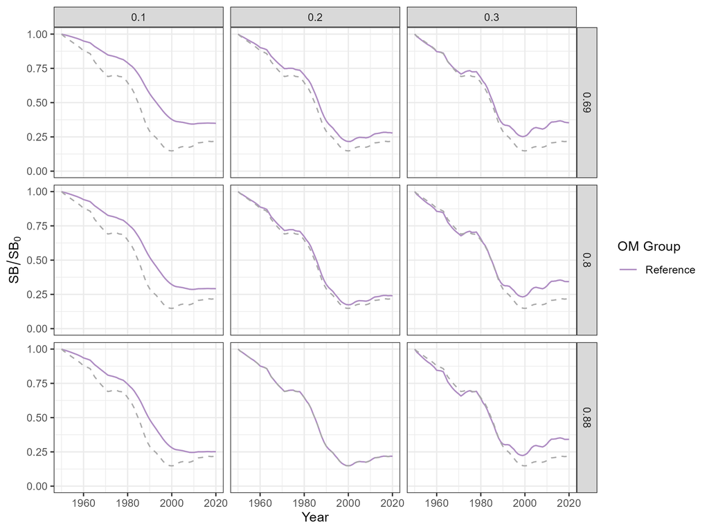

Figure 3. Time-series of estimated relative spawning biomass (SB/SB0) with three levels natural mortality (M; columns) and three levels steepness (h; rows), and the Reference OMs and 0 sets of Robustness OMs (colors). The black dashed line represents the predictions from the 2022 Base Case stock assessment.

## 4.4 SB/SB<sub>MSY</sub>

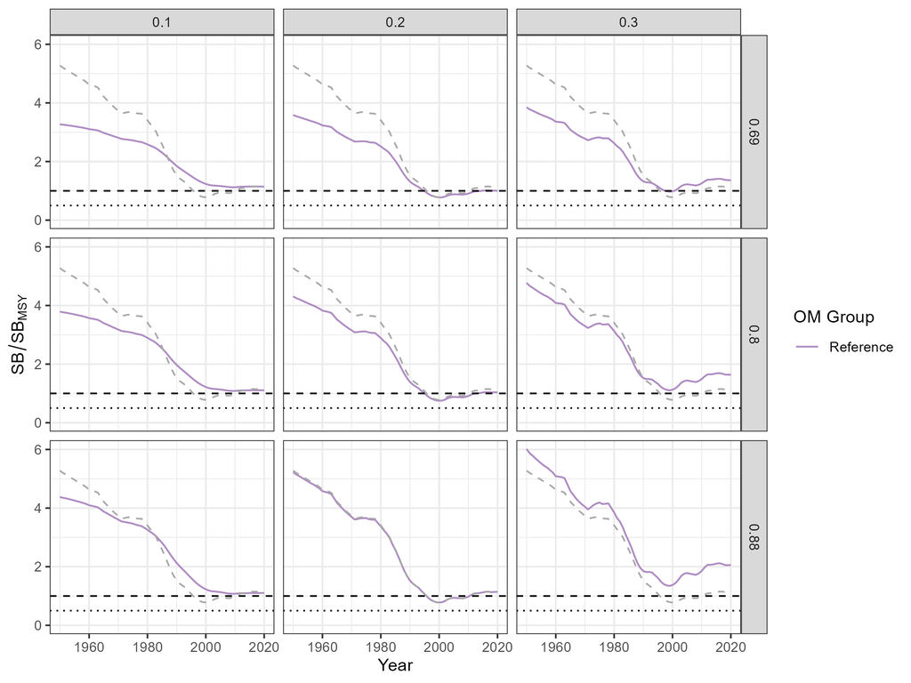

## 4.5 F/F<sub>MSY</sub>

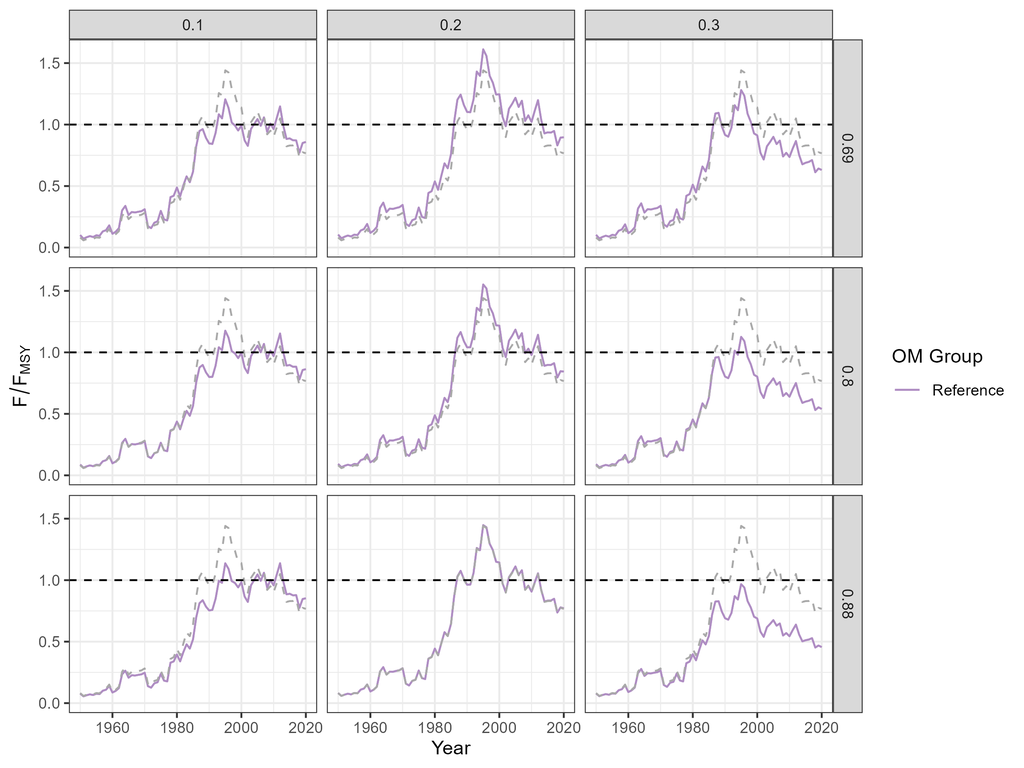